# Data Visualization

MD. TASIN TAZWAR

2023-08-31

## Data Loading and Exploration

Loading Packages

```r
library(tidyverse)
```

```r
library(ggplot2)
library(skimr)
```

Loading Palmer Penguins Dataset and displaying first few rows

```r
dataset <- read.csv("C:/Users/Tasin/Desktop/palmerpenguins.csv")
head(dataset)
```

```
##   species    island bill_length_mm bill_depth_mm flipper_length_mm body_mass_g
## 1  Adelie Torgersen           39.1          18.7               181        3750
## 2  Adelie Torgersen           39.5          17.4               186        3800
## 3  Adelie Torgersen           40.3          18.0               195        3250
## 4  Adelie Torgersen             NA            NA                NA          NA
## 5  Adelie Torgersen           36.7          19.3               193        3450
## 6  Adelie Torgersen           39.3          20.6               190        3650
##      sex year
## 1   male 2007
## 2 female 2007
## 3 female 2007
## 4        2007
## 5 female 2007
## 6   male 2007
```

Providing a description of the dataset’s variables

```r
glimpse(dataset)
```

```
## Rows: 344
## Columns: 8
## $ species           <chr> "Adelie", "Adelie", "Adelie", "Adelie", "Adelie", "A…
## $ island            <chr> "Torgersen", "Torgersen", "Torgersen", "Torgersen", …
## $ bill_length_mm    <dbl> 39.1, 39.5, 40.3, NA, 36.7, 39.3, 38.9, 39.2, 34.1, …
## $ bill_depth_mm     <dbl> 18.7, 17.4, 18.0, NA, 19.3, 20.6, 17.8, 19.6, 18.1, …
## $ flipper_length_mm <dbl> 181, 186, 195, NA, 193, 190, 181, 195, 193, 190, 186…
## $ body_mass_g       <dbl> 3750, 3800, 3250, NA, 3450, 3650, 3625, 4675, 3475, …
## $ sex               <chr> "male", "female", "female", "", "female", "male", "f…
## $ year              <int> 2007, 2007, 2007, 2007, 2007, 2007, 2007, 2007, 2007…
```

There are 8 variables. Among 8 variables, there are 3 types. Chr, Num, and Int. The variables are: species, island, bill_length_mm, bill_depth_mm, flipper_length_mm, body_mass_g, sex, and year.

## Calculating summary statistics (mean, median, standard deviation, max, and min) for each relevant numeric variable

```r
summary_data <- summary(dataset[, c("bill_length_mm", "bill_depth_mm", "flipper_length_mm", "body_mass_g")])

mean_values <- sapply(dataset[, c("bill_length_mm", "bill_depth_mm", "flipper_length_mm", "body_mass_g")], mean, na.rm = TRUE)

median_values <- sapply(dataset[, c("bill_length_mm", "bill_depth_mm", "flipper_length_mm", "body_mass_g")], median, na.rm = TRUE)

sd_values <- sapply(dataset[, c("bill_length_mm", "bill_depth_mm", "flipper_length_mm", "body_mass_g")], sd, na.rm = TRUE)

max_values <- sapply(dataset[, c("bill_length_mm", "bill_depth_mm", "flipper_length_mm", "body_mass_g")], max, na.rm = TRUE)

min_values <- sapply(dataset[, c("bill_length_mm", "bill_depth_mm", "flipper_length_mm", "body_mass_g")], min, na.rm = TRUE)

summary_stat <-data.frame(

  Variabele = c("bill_length_mm", "bill_depth_mm", "flipper_length_mm", "body_mass_g"),
  Mean = mean_values,
  Median = median_values,
  SD = sd_values,
  Max = max_values,
  Min = min_values
)

print(summary_stat)
```

```
##                           Variabele       Mean  Median         SD    Max    Min
## bill_length_mm       bill_length_mm   43.92193   44.45   5.459584   59.6   32.1
## bill_depth_mm         bill_depth_mm   17.15117   17.30   1.974793   21.5   13.1
## flipper_length_mm flipper_length_mm  200.91520  197.00  14.061714  231.0  172.0
## body_mass_g             body_mass_g 4201.75439 4050.00 801.954536 6300.0 2700.0
```

Creating grouped summaries based on penguin species using the `group_by` and `summarize` functions

```r
# Load Library

library(dplyr)



# Creating Grouped summaries

group_summaries <- dataset %>%
  group_by(species) %>%
  summarize(

     mean_bill_length <- mean(bill_length_mm, na.rm = TRUE),
     median_bill_length <- median(bill_length_mm, na.rm = TRUE),
     sd_bill_length <- sd(bill_length_mm, na.rm = TRUE),
     max_bill_length <- max(bill_length_mm, na.rm = TRUE),
     min_bill_length <- min(bill_length_mm, na.rm = TRUE),

     mean_bill_depth <- mean(bill_depth_mm, na.rm = TRUE),
     median_bill_depth <- median(bill_depth_mm, na.rm = TRUE),
     sd_bill_depth <- sd(bill_depth_mm, na.rm = TRUE),
     max_bill_depth <- max(bill_depth_mm, na.rm = TRUE),
     min_bill_depth <- min(bill_depth_mm, na.rm = TRUE),

     mean_flipper_length <- mean(flipper_length_mm, na.rm = TRUE),
     median_flipper_length <- median(flipper_length_mm, na.rm = TRUE),
     sd_flipper_length <- sd(flipper_length_mm, na.rm = TRUE),
     max_flipper_length <- max(flipper_length_mm, na.rm = TRUE),
     min_flipper_length <- min(flipper_length_mm, na.rm = TRUE),

     mean_body_mass <- mean(body_mass_g, na.rm = TRUE),
     median_body_mass <- median(body_mass_g, na.rm = TRUE),
     sd_body_mass <- sd(body_mass_g, na.rm = TRUE),
     max_body_mass <- max(body_mass_g, na.rm = TRUE),
     min_body_mass <- min(body_mass_g, na.rm = TRUE),
  )
print(group_summaries)
```

```
## # A tibble: 3 × 21
##   species   mean_bill_length <- …¹ median_bill_length <…² sd_bill_length <- sd…³
##   <chr>                      <dbl>                  <dbl>                  <dbl>
## 1 Adelie                      38.8                   38.8                   2.66
## 2 Chinstrap                   48.8                   49.6                   3.34
## 3 Gentoo                      47.5                   47.3                   3.08
## # ℹ abbreviated names:
## #   ¹`mean_bill_length <- mean(bill_length_mm, na.rm = TRUE)`,
## #   ²`median_bill_length <- median(bill_length_mm, na.rm = TRUE)`,
## #   ³`sd_bill_length <- sd(bill_length_mm, na.rm = TRUE)`
## # ℹ 17 more variables:
## #   `max_bill_length <- max(bill_length_mm, na.rm = TRUE)` <dbl>,
## #   `min_bill_length <- min(bill_length_mm, na.rm = TRUE)` <dbl>, …
```

**Applying the skimr package**

```r
library(skimr)
dataset %>%
  dplyr::group_by(species) %>%
  skim()
```

Data summary

| Name | Piped data |
| --- | --- |
| Number of rows | 344 |
| Number of columns | 8 |
| _______________________ |  |
| Column type frequency: |  |
| character | 2 |
| numeric | 5 |
| ________________________ |  |
| Group variables | species |

**Variable type: character**

| skim_variable | species | n_missing | complete_rate | min | max | empty | n_unique | whitespace |
| --- | --- | --- | --- | --- | --- | --- | --- | --- |
| island | Adelie | 0 | 1 | 5 | 9 | 0 | 3 | 0 |
| island | Chinstrap | 0 | 1 | 5 | 5 | 0 | 1 | 0 |
| island | Gentoo | 0 | 1 | 6 | 6 | 0 | 1 | 0 |
| sex | Adelie | 0 | 1 | 0 | 6 | 6 | 3 | 0 |
| sex | Chinstrap | 0 | 1 | 4 | 6 | 0 | 2 | 0 |
| sex | Gentoo | 0 | 1 | 0 | 6 | 5 | 3 | 0 |

**Variable type: numeric**

| skim_variable | species | n_missing | complete_rate | mean | sd | p0 | p25 | p50 | p75 | p100 | hist |
| --- | --- | --- | --- | --- | --- | --- | --- | --- | --- | --- | --- |
| bill_length_mm | Adelie | 1 | 0.99 | 38.79 | 2.66 | 32.1 | 36.75 | 38.80 | 40.75 | 46.0 | ▁▆▇▆▁ |
| bill_length_mm | Chinstrap | 0 | 1.00 | 48.83 | 3.34 | 40.9 | 46.35 | 49.55 | 51.08 | 58.0 | ▂▇▇▅▁ |
| bill_length_mm | Gentoo | 1 | 0.99 | 47.50 | 3.08 | 40.9 | 45.30 | 47.30 | 49.55 | 59.6 | ▃▇▆▁▁ |
| bill_depth_mm | Adelie | 1 | 0.99 | 18.35 | 1.22 | 15.5 | 17.50 | 18.40 | 19.00 | 21.5 | ▂▆▇▃▁ |
| bill_depth_mm | Chinstrap | 0 | 1.00 | 18.42 | 1.14 | 16.4 | 17.50 | 18.45 | 19.40 | 20.8 | ▅▇▇▆▂ |
| bill_depth_mm | Gentoo | 1 | 0.99 | 14.98 | 0.98 | 13.1 | 14.20 | 15.00 | 15.70 | 17.3 | ▅▇▇▆▂ |
| flipper_length_mm | Adelie | 1 | 0.99 | 189.95 | 6.54 | 172.0 | 186.00 | 190.00 | 195.00 | 210.0 | ▁▆▇▅▁ |
| flipper_length_mm | Chinstrap | 0 | 1.00 | 195.82 | 7.13 | 178.0 | 191.00 | 196.00 | 201.00 | 212.0 | ▁▅▇▅▂ |
| flipper_length_mm | Gentoo | 1 | 0.99 | 217.19 | 6.48 | 203.0 | 212.00 | 216.00 | 221.00 | 231.0 | ▂▇▇▆▃ |
| body_mass_g | Adelie | 1 | 0.99 | 3700.66 | 458.57 | 2850.0 | 3350.00 | 3700.00 | 4000.00 | 4775.0 | ▅▇▇▃▂ |
| body_mass_g | Chinstrap | 0 | 1.00 | 3733.09 | 384.34 | 2700.0 | 3487.50 | 3700.00 | 3950.00 | 4800.0 | ▁▅▇▃▁ |
| body_mass_g | Gentoo | 1 | 0.99 | 5076.02 | 504.12 | 3950.0 | 4700.00 | 5000.00 | 5500.00 | 6300.0 | ▃▇▇▇▂ |
| year | Adelie | 0 | 1.00 | 2008.01 | 0.82 | 2007.0 | 2007.00 | 2008.00 | 2009.00 | 2009.0 | ▇▁▇▁▇ |
| year | Chinstrap | 0 | 1.00 | 2007.97 | 0.86 | 2007.0 | 2007.00 | 2008.00 | 2009.00 | 2009.0 | ▇▁▆▁▇ |
| year | Gentoo | 0 | 1.00 | 2008.08 | 0.79 | 2007.0 | 2007.00 | 2008.00 | 2009.00 | 2009.0 | ▆▁▇▁▇ |

“skimr” package provides more elaborate and comprehensive summary of each variables. It also provides the visualization like histogram of each variables. It reduces the number of lines of the code that saves time. It helps to find the patterns, anomalies quickly.

# Data Visualization

Creating Different types of Visualization:

**Scatter Plot**

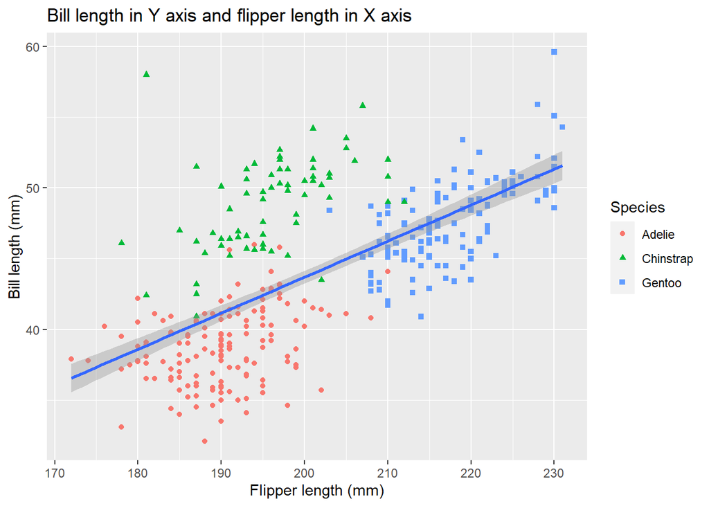

```r
ggplot(
  data = dataset,
  mapping = aes(x = flipper_length_mm, y = bill_length_mm)
) +
  geom_point(aes(color = species, shape = species)) +
  geom_smooth(method = "lm") + labs(
    title = "Bill length in Y axis and flipper length in X axis",
    x = "Flipper length (mm)", y = "Bill length (mm)",
    color = "Species", shape = "Species"
  )
```

The scatter plot shows the relation between Flipper Length and Bill Length of 3 penguin species.The flipper length of ‘Adelle’ and ‘Chinstrap’ are similler type where ‘Chinstrap’ has more taller bill length than Adelle.On the other hand, bill length of Gentoo and Chinstrap have similarities whereas Gantoo has the largest size of the flipper length. The line demonstrate the correlation between the two variables of different penguin species. Closer data point from the line means higher correlation.

**Bar Plot**

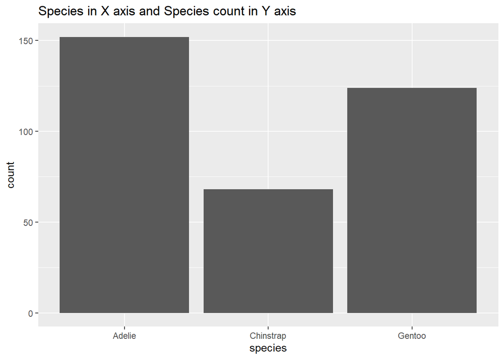

```r
ggplot(dataset, aes(x = species)) +
  geom_bar()+
  labs(
    title = "Species in X axis and Species count in Y axis"
  )
```

The Bar plot shows the categorical variable among the 3 species of penguins with respect to their count. “Chinstrap” is the lowest in number whereas “Gentoo” is the second highest in number near about 125 and the highest number is occupied by “Adelie” that has more than 150 in number.

**Histogram**

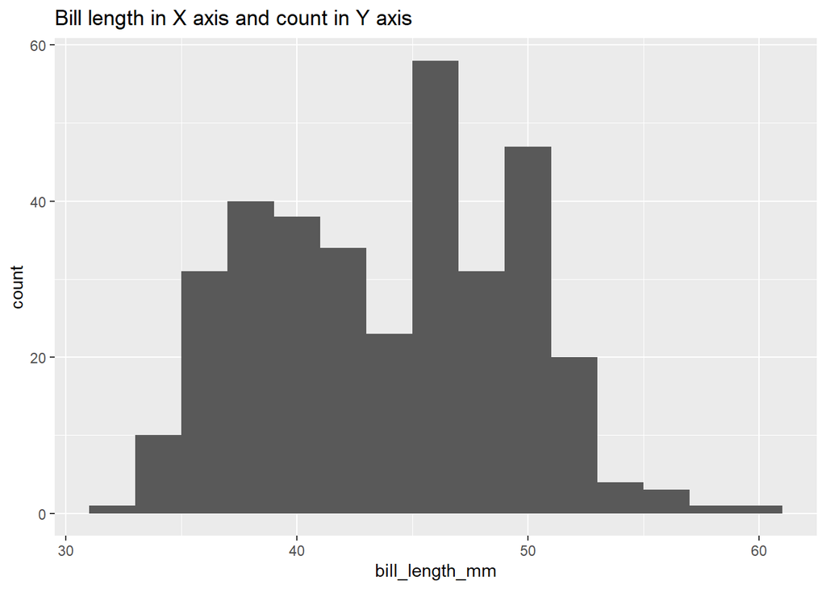

```r
ggplot(dataset, aes(x = bill_length_mm)) +
  geom_histogram(binwidth = 2)+
  labs(
    title = "Bill length in X axis and count in Y axis"
  )
```

The histogram shows the count of values falling into different intervals. It visualizes the number of “bill length” of penguins based on the binwidth value.

# Project Report and Interpretation

There are some similarities that have been found while doing the summarization.For data visualization, I use scatterplot and observe some patterns between two variables of penguins. The plot illustrates the relationship between Flipper Length and Bill Length for three penguin species: Adelle, Chinstrap, and Gentoo.It told that Adelle and Chinstrap penguins have similar types of flipper lengths, but Chinstrap penguins generally have longer bill lengths than Adelle penguins. Besides, Gentoo and Chinstrap penguins have similarities in bill length, while Gentoo penguins have the largest flipper lengths among the three species. Using the bar plot, I have observed the number of each types of species and their corresponding data.

R programming Language is an excellent language for data analysis and visualization. It is a high level user friendly language that has a large number of packages and libraries. Tidyverse is a collection of packages that provide a user friendly data manipulation and visualization workflow. Ggplot is a powerful visualization package that supports to create wide range of graphs, and plots. In this project, ggplot is used for data visualization (scatter plot, Bar plot, and Histogram). Dplyr is another package under tidyverse that allows filtering, summarization of data, grouping data, etc. In this project dplpyr is used for data summarization. Without ggplot package under tidyverse, coding for data visualization through graphs and plots would not user friendly and convenient. So tidyverse is a powerful set of packages that make the data analysis more convenient.